# 3.2. Files

Module M-227-04: Programming for Data Analytics

Instructor: Nadežda Zeņina

Course author: Dmitry Pavlyuk

## Previous lesson review

Warm-up: *Check yourself 3.1 - Functions and Libraries*

- `def` creates a function, `return` gives the result back
- arguments: positional, keyword, default values, `*args`, `**kwargs`
- `assert` tests a function, `lambda` is a one-line function
- `import` gives access to libraries: standard, third-party (`pip install`) and your own `.py` modules

## Today - Files

Files are a usual way store and transfer data. In this topic we review how to read and write files in the following popular formats:

- Text files - reading, writing, simple text statistics
- CSV and Excel files - tables
- JSON files - nested data
- XML files - trees
- Pickle

## Why files?

Until now all our data was typed directly into the code: `students = ['Anna', 'Jānis']`. Real data comes **from files** - exported from a database, downloaded from an open data portal, received from a colleague etc.

Everything we create in Python (lists, dictionaries) lives in **memory** and disappears when the program ends. A **file** keeps the data on the disk and lets us share it.

Reading brings the file into Python objects, writing saves the result back - the formats differ, the idea is always the same

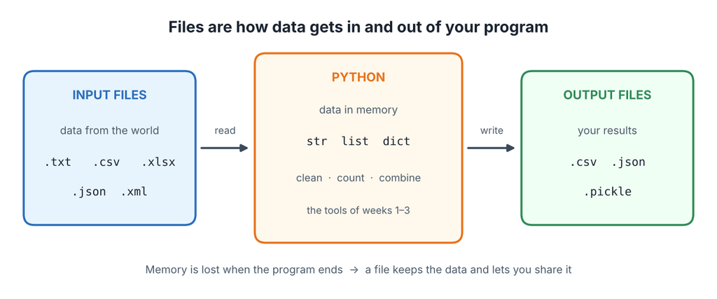

In this topic we review how to read and write files in the most popular formats:

- **Plain text** (`.txt`)
- **CSV** (`.csv`) and **Excel** (`.xlsx`) - tables
- **JSON** (`.json`) - nested data (dictionaries and lists)
- **XML** (`.xml`) - trees
- **Pickle** (`.pickle`) - any Python object, Python only

## Reading a plain text file

```python
with open('/content/alice_in_wonderland.txt', 'r') as file:
    text = file.read()

print(type(text))
print(len(text), "symbols")
print(text[:300])          # the first 300 symbols
```

### Reading a plain text file

`open()` needs the file name, the mode and (for text) the encoding; the `with` block closes the file for you

open() gives Python access to the file and returns a file object.

read() actually retrieves its contents.

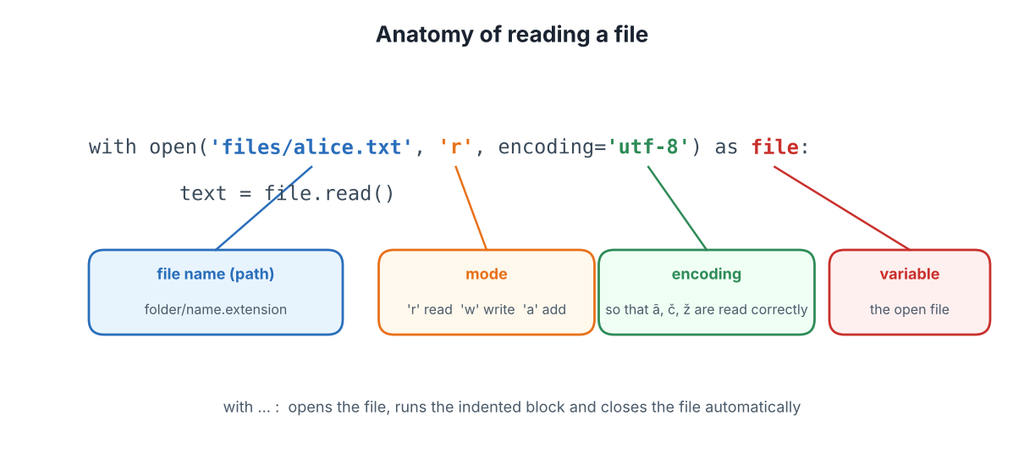

### The whole file as one string

`file.read()` returns the complete content as **one string**. Then everything we know about strings works: `len()`, slicing, `.count()`, `.lower()`, `.split()`.

```python
print(text[-200:])         # the last 200 symbols (negative index counts from the end)
```

### Line by line

A text file is a sequence of **lines**. `for line in file` reads one line at a time - this works even for files that are too big to fit in memory. Every line ends with the new-line symbol `\n`; `line.strip()` removes it.

```python
counter = 0
with open('/content/alice_in_wonderland.txt', 'r', encoding='utf-8') as file:
    for line in file:
        counter = counter + 1
        if counter <= 5:
            print(counter, line.strip())

print("Number of lines:", counter)
```

### Let us implement this as a function for further re-use

`print_file_head` prints the first `count` symbols of any text file (we will use it below to look inside CSV, JSON and XML files before loading them).

```python
def print_file_head(filename, count=500):
    "Print the first 'count' symbols of a text file"
    text = ""
    with open(filename, 'r', encoding='utf-8') as file:
        for line in file:
            text = text +"  "+ str(line)
            if len(text) > count:      # we have enough, no need to read the rest
                break
    print(text[0:count])
    if len(text) >= count:
        print("...")
```

```python
print_file_head('/content/alice_in_wonderland.txt', 200)
```

### Writing a text file

- mode `'w'` - **write**: creates the file (an existing file with the same name is **overwritten**!)
- mode `'a'` - **append**: adds to the end of an existing file
- `file.write()` writes a string; add `\n` yourself to start a new line

```python
with open('/content/demo.txt', 'r') as file:
    text = file.read()

with open('/content/demo.txt', 'w', encoding='utf-8') as file:
    file.write("First line\n")
    file.write("Second line\n")
    file.write("[^A-Za-z ]")

with open('/content/demo.txt', 'a', encoding='utf-8') as file:      # append
    file.write("Third line - added later\n")

print_file_head('/content/demo.txt')
```

### Where are my files?

The `os` library talks to the operating system: list a folder, check that a file exists, see the current folder.

```python
import os
print(os.getcwd())                    # current working folder
print(os.listdir('.'))                # files in the current folder
print(os.listdir('/files'))            # files in the 'files' folder
print(os.path.exists('/demo.txt'))     # does the file exist?
```

### Basic text processing

Preparing and analyzing text to extract useful information, such as the most frequently used words.

```python
print(str(text))
```

```python
import re
text2=re.sub(r'[^A-Za-z ]+', '', text).lower().split()

words = set(text2)
print(f"Total number of words: {len(words)}")

word_stat = {}
for word in words:
    word_stat[word] = text.count(word)
word_stat = sorted(word_stat.items(), key=lambda x: x[1], reverse=True)
print("Most popular words:")
word_stat[:6]
```

## CSV and Excel files

### CSV files

A CSV (comma-separated values) file is a plain text file that has a specific format which allows data to be saved in a table structured format.

Internal CSV structure:

```python
print_file_head('/content/countries_codes.csv', 300)
```

The `csv` library turns every line into a Python list or dictionary - you never split the lines yourself

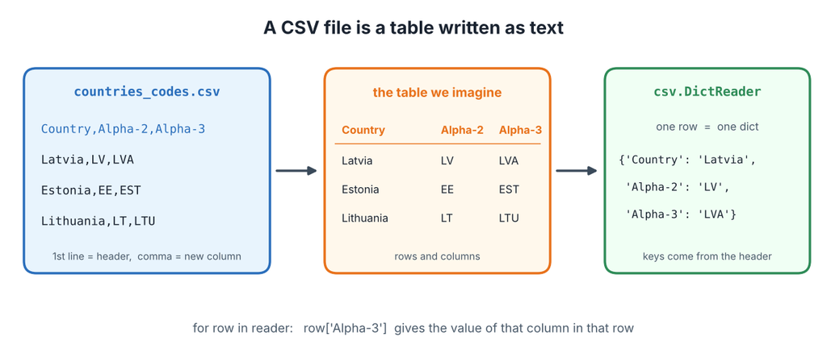

### Reading CSV files: `csv.reader`

`csv.reader` gives every row as a **list** of strings. The header is just the first row.

```python
import csv

with open('/content/countries_codes.csv', 'r') as file:
    reader = csv.reader(file)
    header = next(reader)            # the first row
    print("Header:", header)
    for row in reader:
        if row[1] in ('LV', 'EE', 'LT'):
            print(row)
```

### Reading CSV files: `csv.DictReader`

`csv.DictReader` gives every row as a **dictionary**: the keys are the column names from the header. This is usually more readable - `row['Alpha-3 code']` instead of `row[2]`.

A helper to print only the first items of a long dictionary:

```python
import csv

countries = []

with open('/content/countries_codes.csv', 'r') as file:
    reader = csv.DictReader(file)
    for row in reader:
        countries.append(row)

for country in countries:
    if country['Alpha-2 code'] in ('LV', 'EE', 'LT'):
        print(country)

#for country in countries[:3]:
#    print(country)
```

```python
def print_head(dictionary, count=6):
    "Print the first 'count' items of a dictionary"
    print(dict(list(dictionary.items())[:count]))
```

```python
import csv

iso2toiso3 = {}
with open('/content/countries_codes.csv', 'r') as file:
    reader = csv.DictReader(file)
    for row in reader:
        iso2toiso3[row['Alpha-2 code']] = row['Alpha-3 code']

print(len(iso2toiso3), "countries")
print_head(iso2toiso3)
print(iso2toiso3['LV'])
```

# Everything from a CSV file is a string!

`"33"` is not a number. Convert with `int()` or `float()` before calculating.

```python
with open('/content/countries_codes.csv', 'r', encoding='utf-8') as file:
    rows = list(csv.DictReader(file))      # all rows as a list of dictionaries

print("Number of observations:", len(rows))
print(rows[0])
print(type(rows[0]['Latitude (average)']))
```

```python
northern = 0
for row in rows:
    if float(row['Latitude (average)']) > 0:
        northern = northern + 1
print("Countries in the northern hemisphere:", northern)
```

### Real-world CSV files (for example data.gov.lv)

Not every CSV is as clean as our example. The usual problems and their fixes:

- columns separated by `;` instead of `,` → `csv.DictReader(file, delimiter=';')`
- a strange symbol at the very beginning (`\ufeff`) → `encoding='utf-8-sig'`
- decimal comma `3,5` → `float(value.replace(',', '.'))`
- empty values `""` → check before converting: `if value != "":`

Always look at the file first with `print_file_head()`to understand the CSV file's structure before reading and processing it.

```python
import urllib.request

url = "https://raw.githubusercontent.com/nzenina2/python-da-main-nz/main/week3/files/countries_codes.csv"
urllib.request.urlretrieve(url, "my_download2.csv")     # (link, file name on disk)

print_file_head("my_download2.csv", 150)
```

### Reading XLSX files

XLSX is part of Microsoft Office Open XML specification. XLSX is a proprietary zipped, XML-based file format.

It is a binary (zipped) format, so we need a library - `openpyxl` (already installed in Google Colab).

```python
import openpyxl

workbook = openpyxl.load_workbook('/content/country_population.xlsx')
print(workbook.sheetnames)
```

```python
sheet = workbook['country_population']
print("Rows:", sheet.max_row, " Columns:", sheet.max_column)
print(sheet['A1'].value, "|", sheet['B2'].value, "|", sheet['C3'].value)
```

```python
#create a dictionary mapping each country's code to its population in 2021.
population_dict = {}
for row in range(1, sheet.max_row):
    country_dict = {}
    for col in sheet.iter_cols(1, sheet.max_column):
        country_dict[col[0].value] = col[row].value
    population_dict[country_dict['Country Code']] = country_dict['Population, 2021']
print_head(population_dict)
```

Note: Excel keeps numbers as numbers (`int`), unlike CSV. In week 5 `pandas` will read CSV and Excel files into a table with one line of code - but it is important to understand what happens inside.

## JSON files

JSON (JavaScript Object Notation) is an open standard file format and data interchange format that uses human-readable text to store and transmit data objects consisting of attribute–value pairs and arrays.

Internal JSON structure:

```python
print_file_head('/content/countries.json', 400)
```

JSON objects become dictionaries and JSON arrays become lists - the nested structures of lesson 2.3

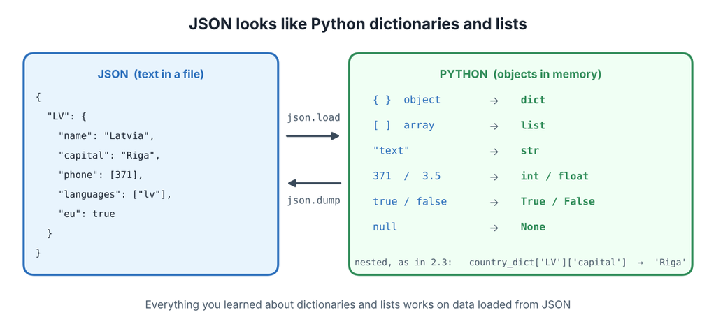

### Reading JSON files

`json.load(file)` Reads JSON from the file and converts it into Python objects (typically dictionaries and lists).

`json.dumps(...)` Converts a Python object into a JSON-formatted string.

```python
import json

f = open('/content/countries.json', encoding= 'utf-8')
country_dict = json.load(f)
f.close()
print(json.dumps(country_dict["LV"], indent=2))
```

```python
import json

with open('/content/countries.json', 'r', encoding='utf-8') as file:
    country_dict = json.load(file)

print(type(country_dict))
print(len(country_dict), "countries")
print(country_dict['LV'])
```

### Working with the loaded data

`country_dict` is a dictionary of dictionaries: the key is the ISO-2 code, the value is a dictionary with the country's attributes. Some attributes are lists (`currency`, `languages`).

```python
latvia = country_dict['LV']
print(latvia['name'], "-", latvia['capital'])
print(latvia['currency'])              # a list
print(latvia['currency'][0])           # the first currency
print(latvia['languages'])
```

```python
# all countries with the euro
for code in country_dict:
    country = country_dict[code]
    if 'EUR' in country['currency']:
        print(country['name'], end=", ")
```

### `json.dumps` - pretty printing

`json.dumps(obj, indent=2)` turns a Python object into a nicely formatted **string** (s = string). Useful to look at nested data.

```python
print(json.dumps(country_dict['LV'], indent=2))
```

## XML files

XML (Extensible Markup Language) is a markup language and file format for storing, transmitting, and reconstructing arbitrary data. The data is written as **elements** `<tag> ... </tag>` nested inside each other, with optional **attributes** `name="..."`. Many official statistics (World Bank, Eurostat, state registers) published as XML.

Internal XML structure:

```python
print_file_head('/content/countries_gdp.xml', 600)
```

The parser builds a tree; we walk down from the root to the records and read the fields

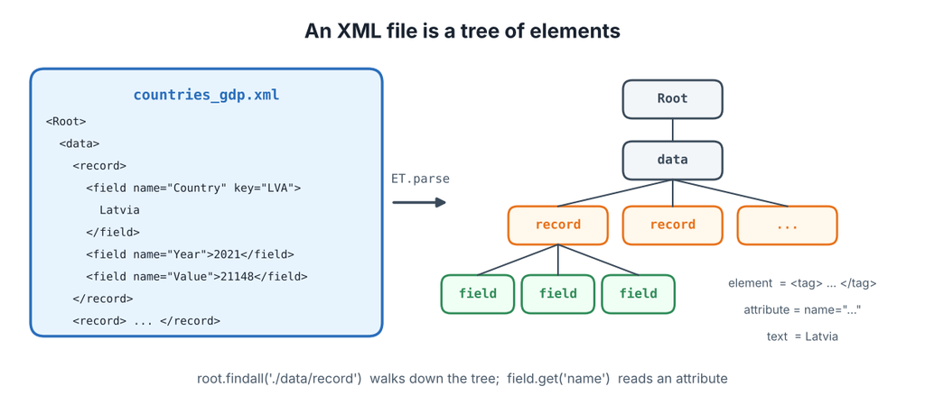

### Reading XML files

`xml.etree.ElementTree` (standard library) parses the file into a tree. `findall()` finds the elements by a path, `.get()` reads an attribute, `.text` reads the text inside the element.

```python
#Read an XML file containing GDP data and converts its records into a list of Python dictionaries.
import xml.etree.ElementTree as ET

tree = ET.parse('/content/countries_gdp.xml')
root = tree.getroot()
records = root.findall('./data/record')
print("Number of records:", len(records))

record_list = []
for record in records:
    fields = {}
    for field in record.findall('field'):
        name = field.get('name')                       # attribute 'name'
        if field.get('key') is not None:               # some fields keep the code in the attribute 'key'
            value = field.get('key')
        else:
            value = field.text                         # the text inside <field> ... </field>
        fields[name] = value
    record_list.append(fields)

print(record_list[0])
print(record_list[-1])
```

### Preprocessing - selecting the most recent value

Every country has one record per year; many old years have no value (`None`). We keep, for every country, the GDP per capita of the **latest year with data**.

```python
gdp_dict = {}       # Store the latest GDP value for each country
latest_year = {}    # Store the latest available year for each country

for record in record_list:               # Loop through all GDP records
    if record['Value'] is not None:       # Skip records with missing GDP values
        country = record['Country or Area']            # ISO-3 code (from the 'key' attribute)
        year = int(record['Year'])
        value = float(record['Value'])
        if country not in latest_year or latest_year[country] < year:
            latest_year[country] = year
            gdp_dict[country] = value

print(len(gdp_dict), "countries with GDP data")
print("Latvia:", round(gdp_dict['LVA']), "USD per capita in", latest_year['LVA'])
```

## Example: extending the data

Now we are going to extent the country_dict information on countries (read from theJSON file) with information on population (population_dict from the XLSX file) and gdp (gdp_dict from XML file). iso2toiso3 dictionary from the CSV file will be used for matching ISO-2 country codes (used in country_dict) and ISO-3 country codes (used in population_dict and gdp_dict).

| variable | from | key | content |
| --- | --- | --- | --- |
| `country_dict` | JSON | ISO-2 (`LV`) | name, capital, currency, languages |
| `population_dict` | XLSX | ISO-3 (`LVA`) | population 2021 |
| `gdp_dict` | XML | ISO-3 (`LVA`) | GDP per capita |
| `iso2toiso3` | CSV | ISO-2 → ISO-3 | the "translation" between the two code systems |

Let us **extend** `country_dict` with the population and the GDP. The CSV dictionary matches the ISO-2 codes with the ISO-3 codes.

```python
print("Country:", country_dict['LV']) #JSON
```

```python
print("Population:", population_dict['LVA']) #Excel
```

```python
print("GDP per capita:", gdp_dict['LVA']) #xml
```

```python
for country_code in country_dict:  # Loop through all country codes
    country = country_dict[country_code]  # Get the current country's data
    if country_code in iso2toiso3:  # Check if the country has an ISO-3 code
        iso2_code = iso2toiso3[country_code]  # Convert ISO-2 to ISO-3 (LV → LVA)
        if iso2_code in population_dict:  # Check if population data exists
            country["population"] = population_dict[iso2_code]  # Add population to the country
        if iso2_code in gdp_dict:  # Check if GDP data exists
            country["GDP_per_capita"] = gdp_dict[iso2_code]  # Add GDP per capita to the country

print(json.dumps(country_dict['LV'], indent=2))  # Print Latvia's updated data as formatted JSON
```

## Saving data to files

### Writing JSON

`json.dump(obj, file)` writes a Python object (dictionaries, lists, strings, numbers, `True/False/None`) to a file. `indent=2` makes the file readable, `ensure_ascii=False` keeps letters like `ā`, `ž` as they are.

We store the extended country_dict dictionary into a JSON file:

```python
with open("/content/countries_extended.json", "w") as outfile:
    outfile.write(json.dumps(country_dict, indent=2))

print_file_head('/content/countries_extended.json', 300)
```

### Writing CSV

`csv.writer` writes a row from a list or tuple; `newline=''` prevents empty lines on Windows.

Now we store the selected field country_dict of into a CSV file:

```python
with open('/content/countries_extended.csv', 'w', encoding='utf-8', newline='') as file:
    writer = csv.writer(file)
    writer.writerow(('ISO2', 'Name', 'Population', 'GDP per capita'))        # header
    for code in country_dict:
        country = country_dict[code]
        writer.writerow((code,
                         country['name'],
                         country['population'] if 'population' in country else "",
                         country['GDP_per_capita'] if 'GDP_per_capita' in country else ""))

print_file_head('/content/countries_extended.csv', 250)
```

The file `countries_extended.csv` can now be opened in Excel - this is how results leave Python.

### Pickle files

Pickle can be used to serialize Python object structures, which refers to the process of converting an object in the memory to a byte stream that can be stored as a binary file on disk.

Note the modes `'wb'` / `'rb'` - **b** for binary, no encoding.

pickle.dump() — saves the Python dictionary into that file.

```python
import pickle

with open('/content/countries_extended.pickle', 'wb') as file:
    pickle.dump(country_dict, file)
```

```python
with open('/content/countries_extended.pickle', 'rb') as file:
    country_dict_stored = pickle.load(file)

print("Successfully stored?", country_dict_stored == country_dict)
print(country_dict_stored['LV']['name'], country_dict_stored['LV']['population'])
```

## Summary

Every format has its library, but the workflow is always the same

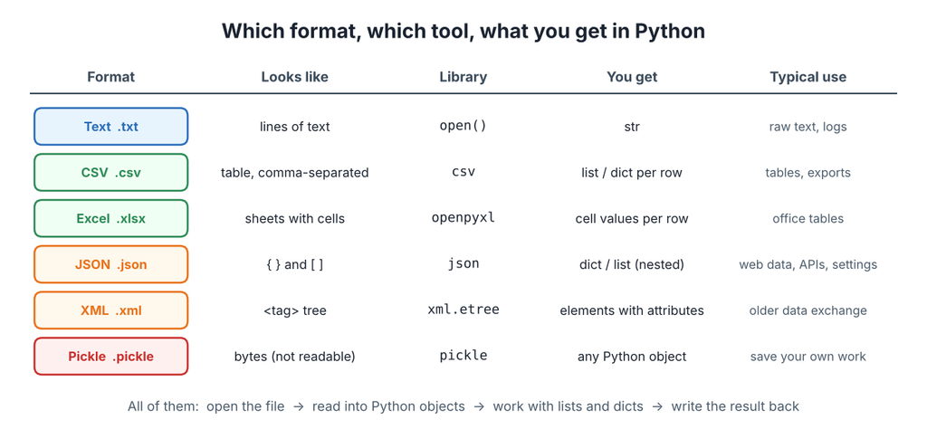